# EDA

Shafeek Saleem

11/21/2020

## Setup

### Load packages

```r
library(ggplot2)
library(dplyr)
library(statsr)
library(xgboost)
library(MLmetrics)
library(lubridate)
library(corrplot)
library(truncnorm)
library(gridExtra)
```

```r
setwd('C:\\Users\\octavei\\OneDrive - John Keells Holdings PLC\\Desktop\\MyFiles\\UoC Mini Hackathon')
```

### Load data

```r
train <- read.csv("train_data.csv",na.strings = "")
test <- read.csv("test_data.csv",na.strings = "")
```

### Change order of variables

```r
train <- train %>% select(colnames(test),"app_status")
```

## Explonatory Data Analysis

### Feature description

The features used in the structure are:

NURSERY Evaluation of applications for nursery schools . EMPLOY Employment of parents and child’s nursery . . parents Parents’ occupation . . has_nurs Child’s nursery . STRUCT_FINAN Family structure and financial standings . . STRUCTURE Family structure . . . form Form of the family . . . children Number of children . . housing Housing conditions . . finance Financial standing of the family . SOC_HEALTH Social and health picture of the family . . social Social conditions . . health Health conditions

### Initial analysis

```r
str(train)
```

```
## 'data.frame':    10368 obs. of  10 variables:
##  $ ID        : int  1 2 3 4 5 6 7 8 9 10 ...
##  $ parents   : Factor w/ 3 levels "great_pret","pretentious",..: 3 2 2 1 1 1 1 2 3 1 ...
##  $ has_nurs  : Factor w/ 5 levels "critical","improper",..: 3 5 4 2 3 5 2 5 5 1 ...
##  $ form      : Factor w/ 4 levels "complete","completed",..: 1 2 4 1 2 3 1 3 4 2 ...
##  $ children  : Factor w/ 4 levels "1","2","3","more": 3 1 1 1 1 1 4 1 3 3 ...
##  $ housing   : Factor w/ 3 levels "convenient","critical",..: 2 1 3 1 1 1 1 2 2 1 ...
##  $ finance   : Factor w/ 2 levels "convenient","inconv": 1 2 1 1 1 2 1 1 2 2 ...
##  $ social    : Factor w/ 3 levels "nonprob","problematic",..: 2 1 3 1 3 3 2 1 2 3 ...
##  $ health    : Factor w/ 3 levels "not_recom","priority",..: 1 1 2 3 2 1 1 2 1 1 ...
##  $ app_status: int  0 0 1 1 1 0 0 0 0 0 ...
```

**Decisions -**

1. `app_status` should be Factor variables.
2. `ID` should be removed.

```r
train <- train %>% select(-ID)
test <- test %>% select(-ID)
train$app_status <- as.factor(train$app_status)
train$has_nurs = factor(train$has_nurs, levels = c("proper", "less_proper", "improper", "critical", "very_crit"))
train$housing = factor(train$housing, levels = c("convenient", "less_conv", "critical"))
train$social = factor(train$social, levels = c("nonprob", "slightly_prob", "problematic"))
train$form = factor(train$form, levels = c("complete", "completed", "incomplete", "foster"))
```

### Handling missing/ null values

```r
train %>% summarise(Feature = colnames(train),"Total MissingValues" = colSums(is.na(train)),"MissingValues(%)" = round(colSums(is.na(train))/n()*100,2))
```

```
##      Feature Total MissingValues MissingValues(%)
## 1    parents                   0                0
## 2   has_nurs                   0                0
## 3       form                   0                0
## 4   children                   0                0
## 5    housing                   0                0
## 6    finance                   0                0
## 7     social                   0                0
## 8     health                   0                0
## 9 app_status                   0                0
```

```r
test %>% summarise(Feature = colnames(test),"Total MissingValues" = colSums(is.na(test)), "MissingValues(%)" = round(colSums(is.na(test))/n()*100,2))
```

```
##    Feature Total MissingValues MissingValues(%)
## 1  parents                   0                0
## 2 has_nurs                   0                0
## 3     form                   0                0
## 4 children                   0                0
## 5  housing                   0                0
## 6  finance                   0                0
## 7   social                   0                0
## 8   health                   0                0
```

**Observations and Decisions -**

1. No missing or null values found in both train and test datasets.

### Target class/Y distribution

```r
train %>% group_by(app_status) %>% summarise(perc = n()*100/nrow(train))
```

```
## # A tibble: 2 x 2
##   app_status  perc
##   <fct>      <dbl>
## 1 0           64.6
## 2 1           35.4
```

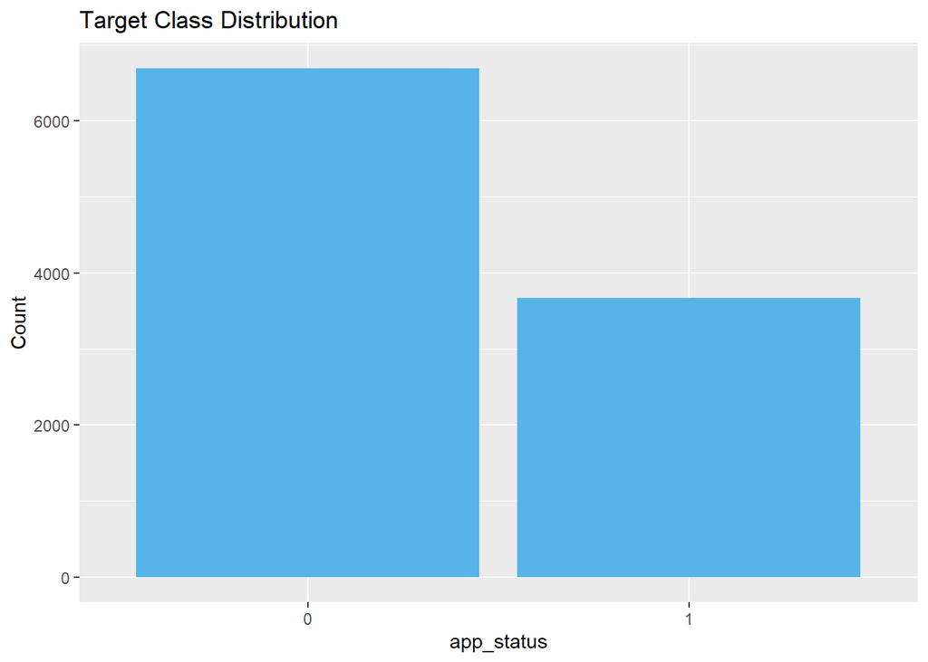

```r
train %>% ggplot(aes(x=as.factor(app_status)))+geom_bar(fill = "#56B4E9")+labs(x='app_status',y='Count',title = "Target Class Distribution")
```

**Note -**

Target class distribution is slightly imbalanced - Train dataset contains 64.5% of class 0 and 35.5% of class 1. One good solution would be up sampling which can cuase over fitting. Another solution would be to use weight parameters with algorithms like xgboost.

## Multivariate analysis - Features vs Target

## 1. Employment

### 1.1. Employment of parents

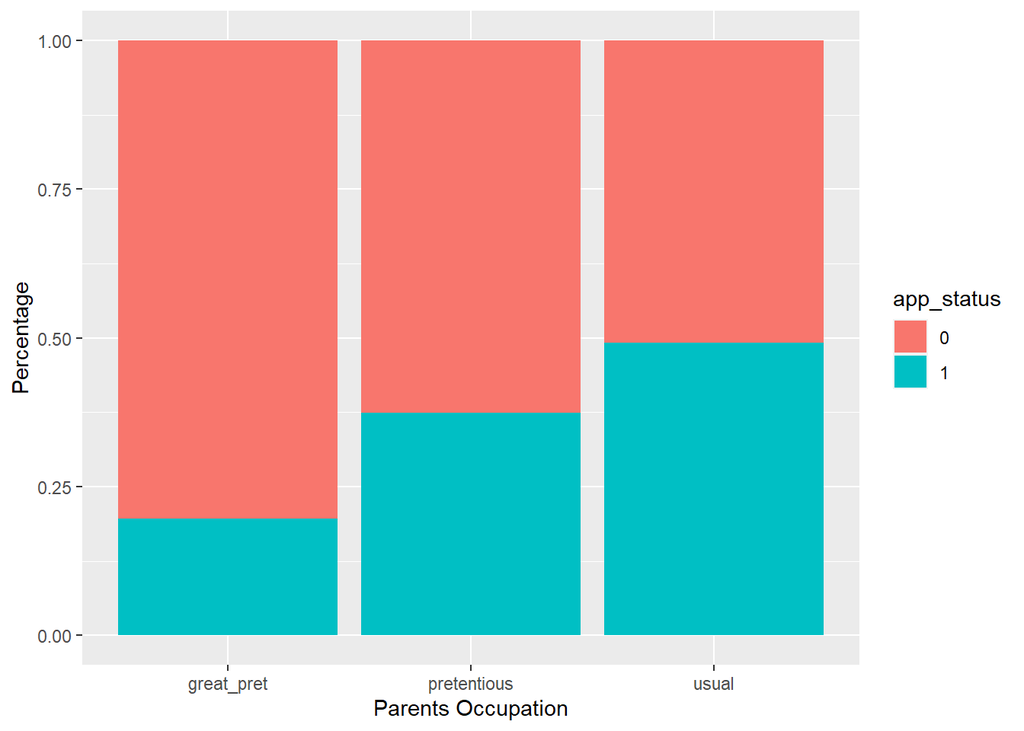

```r
train %>%
  ggplot(aes(x=parents, fill=app_status))+geom_bar(position="fill")+labs(x='Parents Occupation',y='Percentage')
```

```r
train %>%
  group_by(parents) %>%
  summarise(Count = n(), "App status Rate ( % )" = sum(app_status==1)/n()*100, .groups = 'drop')
```

```
## # A tibble: 3 x 3
##   parents     Count `App status Rate ( % )`
##   <fct>       <int>                   <dbl>
## 1 great_pret   3475                    19.6
## 2 pretentious  3418                    37.5
## 3 usual        3475                    49.3
```

**Note -** Feature class distribution is balanced.

**Observations -**

1. Applications with, parent’s employment as usual, have ~30% more chance to get accepted than parents with great_pret employment.

### 1.2. Child’s nursery

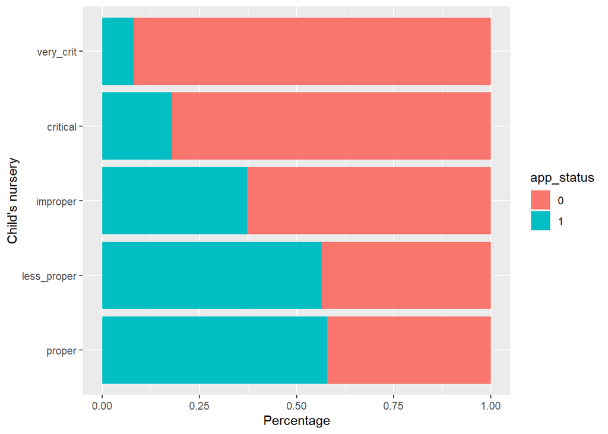

```r
train %>%
  ggplot(aes(x=has_nurs, fill=app_status))+geom_bar(position="fill")+coord_flip() +labs(x="Child's nursery",y='Percentage')
```

```r
train %>%
  group_by(has_nurs) %>%
  summarise(Count = n(), "App status Rate ( % )" = sum(app_status==1)/n()*100, .groups = 'drop')
```

```
## # A tibble: 5 x 3
##   has_nurs    Count `App status Rate ( % )`
##   <fct>       <int>                   <dbl>
## 1 proper       2050                   57.9
## 2 less_proper  2058                   56.4
## 3 improper     2088                   37.3
## 4 critical     2108                   18.0
## 5 very_crit    2064                    8.19
```

**Note -** Feature class distribution is balanced.

**Observations -**

1. The probability of an application getting accepted is increasing with the child’s nursery from very cretical to proper (~8% to ~58%).

## 2. Family structure and Financial standings

### 2.1. Family structure

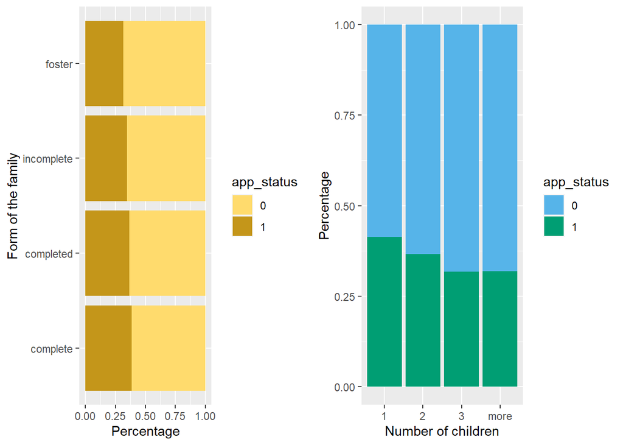

```r
plot1 <- train %>%
  ggplot(aes(x=form, fill=app_status))+
  geom_bar(position="fill")+
  labs(x='Form of the family',y='Percentage')+
  scale_fill_manual(values = c("#FFDB6D", "#C4961A"))+
  coord_flip()

plot2 <- train %>%
  ggplot(aes(x=children, fill=app_status))+
  geom_bar(position="fill")+
  labs(x='Number of children',y='Percentage')+
  scale_fill_manual(values = c("#56B4E9", "#009E73"))

grid.arrange(plot1, plot2, ncol=2)
```

```r
train %>%
  group_by(form) %>%
  summarise(Count = n(), "App status Rate ( % )" = sum(app_status==1)/n()*100, .groups = 'drop')
```

```
## # A tibble: 4 x 3
##   form       Count `App status Rate ( % )`
##   <fct>      <int>                   <dbl>
## 1 complete    2604                    38.8
## 2 completed   2589                    36.6
## 3 incomplete  2604                    34.6
## 4 foster      2571                    31.6
```

```r
train %>%
  group_by(children) %>%
  summarise(Count = n(), "App status Rate ( % )" = sum(app_status==1)/n()*100, .groups = 'drop')
```

```
## # A tibble: 4 x 3
##   children Count `App status Rate ( % )`
##   <fct>    <int>                   <dbl>
## 1 1         2592                    41.4
## 2 2         2587                    36.6
## 3 3         2632                    31.8
## 4 more      2557                    32.0
```

**Note -** class distribution of both classes are balanced.

**Observations -**

1. Applications with, complete family form have ~7% more chance to be accepted than foster families. The order for probabilty of acceptance is foster < incomplete < completed < complete.
2. The probability of an application getting accepted is decreasing with the number of children in a family (~41% to ~32%).

### 2.2. Housing conditions

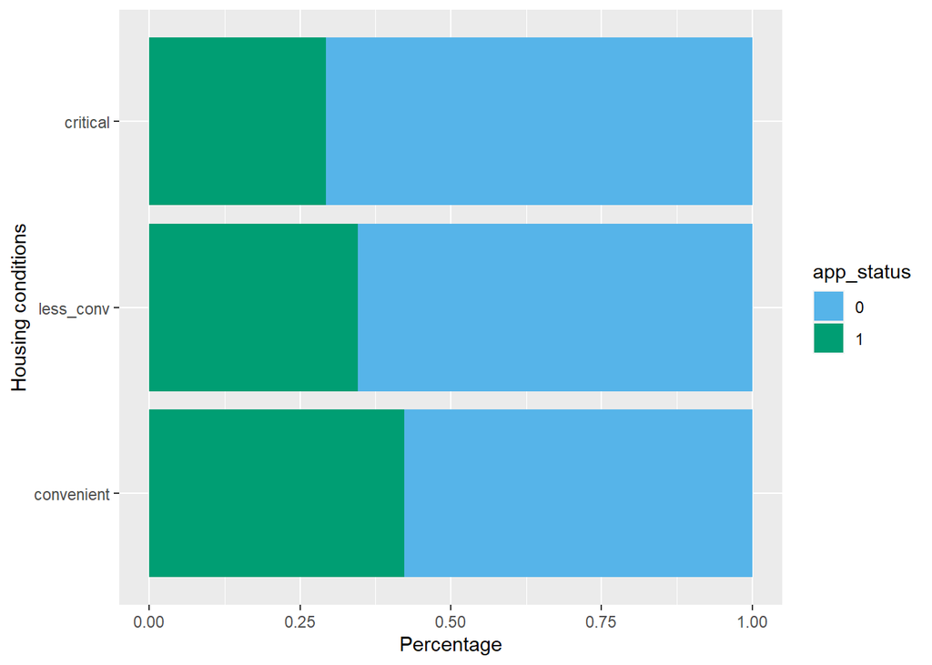

```r
train %>%
  ggplot(aes(x=housing, fill=app_status))+
  geom_bar(position="fill")+coord_flip()+
  labs(x="Housing conditions",y='Percentage')+
  scale_fill_manual(values = c("#56B4E9", "#009E73"))
```

```r
train %>%
  group_by(housing) %>%
  summarise(Count = n(), "App status Rate ( % )" = sum(app_status==1)/n()*100, .groups = 'drop')
```

```
## # A tibble: 3 x 3
##   housing    Count `App status Rate ( % )`
##   <fct>      <int>                   <dbl>
## 1 convenient  3477                    42.3
## 2 less_conv   3472                    34.6
## 3 critical    3419                    29.3
```

**Note -** Feature class distribution is balanced.

**Observations -**

1. Applications with, convenient housing conditions have ~13%% more chance to be accepted than applications with critical house conditions.

### 2.3. Financial standing of the family

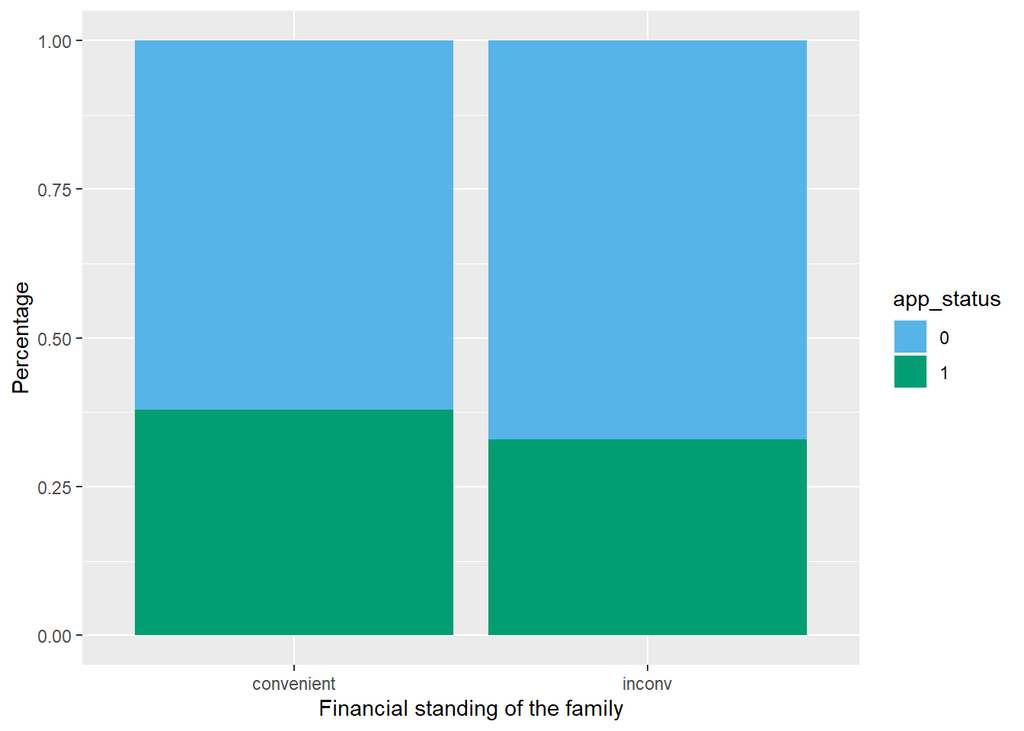

```r
train %>%
  ggplot(aes(x=finance, fill=app_status))+
  geom_bar(position="fill")+
  labs(x="Financial standing of the family",y='Percentage')+
  scale_fill_manual(values = c("#56B4E9", "#009E72"))
```

```r
train %>%
  group_by(finance) %>%
  summarise(Count = n(), "App status Rate ( % )" = sum(app_status==1)/n()*100, .groups = 'drop')
```

```
## # A tibble: 2 x 3
##   finance    Count `App status Rate ( % )`
##   <fct>      <int>                   <dbl>
## 1 convenient  5159                    38.0
## 2 inconv      5209                    32.9
```

**Note -** Feature class distribution is balanced.

**Observations -**

1. Applications with, convenient financial standings have ~5% more chance to be accepted than applications with inconvenient financial standings. * * *

## 3. Social and health picture of the family

### 3.1. Social conditions

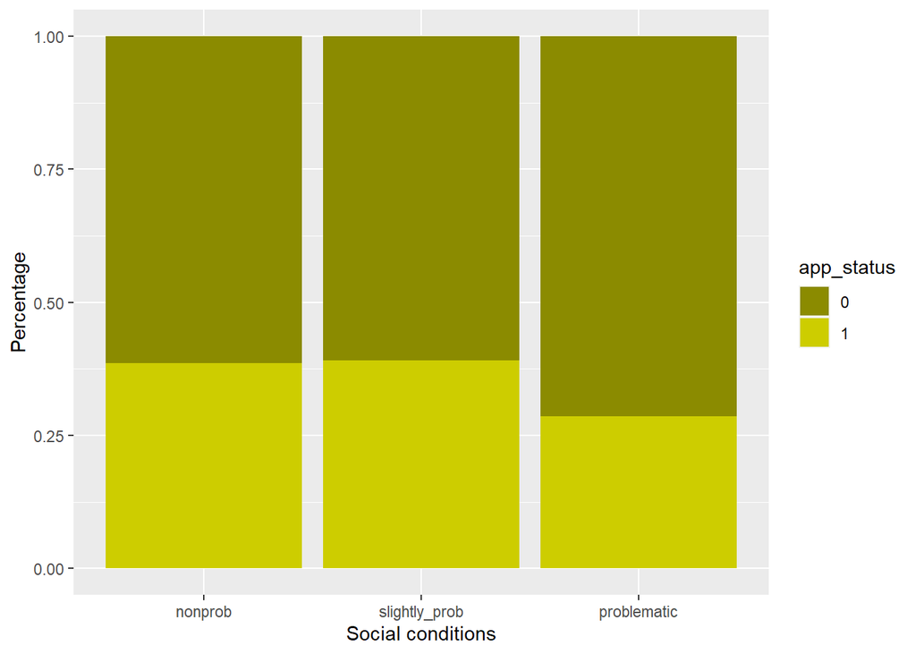

```r
train %>%
  ggplot(aes(x=social, fill=app_status))+
  geom_bar(position="fill")+
  labs(x="Social conditions",y='Percentage')+
  scale_fill_manual(values = c("yellow4", "yellow3"))
```

```r
train %>%
  group_by(social) %>%
  summarise(Count = n(), "App status Rate ( % )" = sum(app_status==1)/n()*100, .groups = 'drop')
```

```
## # A tibble: 3 x 3
##   social        Count `App status Rate ( % )`
##   <fct>         <int>                   <dbl>
## 1 nonprob        3427                    38.6
## 2 slightly_prob  3496                    39.1
## 3 problematic    3445                    28.6
```

**Note -** Feature class distribution is balanced.

**Observations -**

1. Applications with non-problemetic or slightly-problemetic social conditions have almost equal chance of getting accepted.
2. But applications with problemetic social conditions have ~10% lesser chance of getting accepted than the other two categories. * * *

### 3.2. Health conditions

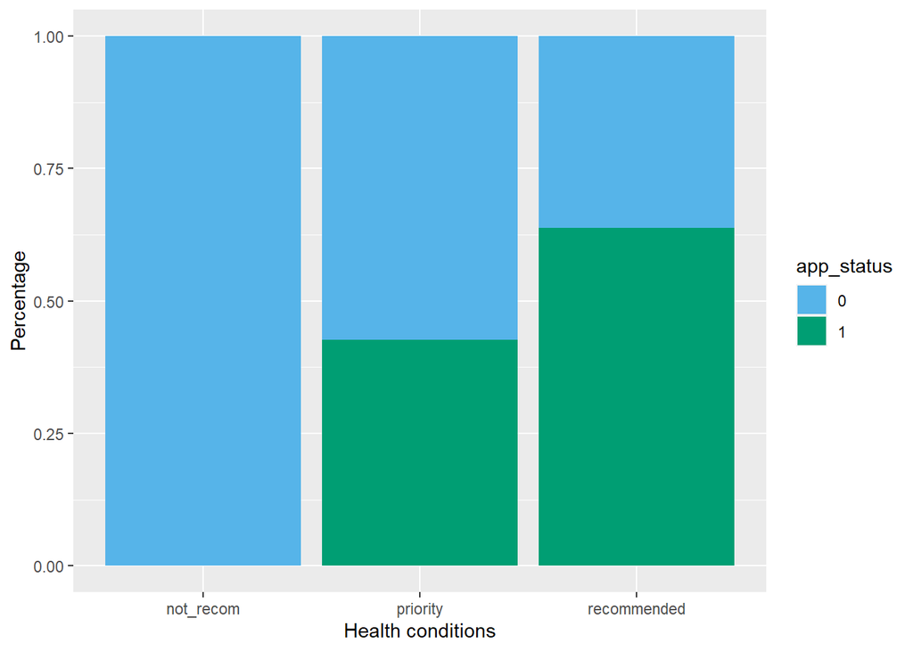

```r
train %>%
  ggplot(aes(x=health, fill=app_status))+
  geom_bar(position="fill")+
  labs(x="Health conditions",y='Percentage')+
  scale_fill_manual(values = c("#56B4E9", "#009E73"))
```

```r
train %>%
  group_by(health) %>%
  summarise(Count = n(), "App status Rate ( % )" = sum(app_status==1)/n()*100, .groups = 'drop')
```

```
## # A tibble: 3 x 3
##   health      Count `App status Rate ( % )`
##   <fct>       <int>                   <dbl>
## 1 not_recom    3465                     0
## 2 priority     3456                    42.7
## 3 recommended  3447                    63.8
```

**Note -** Feature class distribution is balanced.

**Observations -**

1. Applications with not-recommended health conditions have 100% chance of getting rejected. Health conditions play a major role in selection of applications.
2. Applications with recommended health conditions have ~64% chance of getting accepted.
3. Applications with priority health conditions have ~43% chance of getting accepted.